# STAT167 Project Work: Difference between STEM and non-STEM - Spring 2020

### (II.) Assessing Data

**Briefing over some descriptive statistics I wanted to analyze.**  
**Petroleum Engineering has low unemployment rate and a high median salary. Biology, Computer Science, Business, and Accounting are the most impacted majors. There exists a major called Metallurgical engineering which is the study of metals.**

```r
#finding top 5 stem median salaries
STEM_mediansalary <- group_by(STEM, Major)
sal_sum <- summarise(STEM_mediansalary, med_salary = Median)
med_sal_STEM <- arrange(sal_sum, desc(med_salary))
head(med_sal_STEM, 5)
## # A tibble: 5 x 2
##   Major                                     med_salary
##   <chr>                                          <dbl>
## 1 PETROLEUM ENGINEERING                         110000
## 2 MINING AND MINERAL ENGINEERING                 75000
## 3 METALLURGICAL ENGINEERING                      73000
## 4 NAVAL ARCHITECTURE AND MARINE ENGINEERING      70000
## 5 CHEMICAL ENGINEERING                           65000

#finding top 5 non stem median salaries
NONSTEM_mediansalary <- group_by(NONSTEM, Major)
nsal_sum <- summarise(NONSTEM_mediansalary, med_salary = Median)
med_sal_NONSTEM <- arrange(nsal_sum, desc(med_salary))
head(med_sal_NONSTEM, 5)
## # A tibble: 5 x 2
##   Major                                         med_salary
##   <chr>                                              <dbl>
## 1 ACTUARIAL SCIENCE                                  62000
## 2 COURT REPORTING                                    54000
## 3 MANAGEMENT INFORMATION SYSTEMS AND STATISTICS      51000
## 4 c                                                  50000
## 5 CONSTRUCTION SERVICES                              50000

#finding top5 most popular in STEM
STEM_majors <- group_by(STEM, Major)
overview <- summarise(STEM_majors, total = sum(Total))
most_popularSTEM <- arrange(overview, desc(total))
head(most_popularSTEM, 5)
## # A tibble: 5 x 2
##   Major                   total
##   <chr>                   <dbl>
## 1 BIOLOGY                280709
## 2 NURSING                209394
## 3 COMPUTER SCIENCE       128319
## 4 MECHANICAL ENGINEERING  91227
## 5 ELECTRICAL ENGINEERING  81527

#finding top5 most popular in NONSTEM
NONSTEM_majors <- group_by(NONSTEM, Major)
overview <- summarise(NONSTEM_majors, total = sum(Total))
most_popularNONSTEM <- arrange(overview, desc(total))
head(most_popularNONSTEM, 5)
## # A tibble: 5 x 2
##   Major                                   total
##   <chr>                                   <dbl>
## 1 BUSINESS MANAGEMENT AND ADMINISTRATION 329927
## 2 GENERAL BUSINESS                       234590
## 3 COMMUNICATIONS                         213996
## 4 MARKETING AND MARKETING RESEARCH       205211
## 5 ACCOUNTING                             198633

#finding top 5 lowest unemployment rates for STEM
unemploymentrateSTEM_majors <- group_by(STEM, Major)
rate <- summarise(unemploymentrateSTEM_majors, unemployment_rate = Unemployment_rate)
least_unemployment_rate_STEM <- arrange(rate, -desc(unemployment_rate))
head(least_unemployment_rate_STEM, 5)
## # A tibble: 5 x 2
##   Major                                     unemployment_rate
##   <chr>                                                 <dbl>
## 1 BOTANY                                              0
## 2 MATHEMATICS AND COMPUTER SCIENCE                    0
## 3 SOIL SCIENCE                                        0
## 4 ENGINEERING MECHANICS PHYSICS AND SCIENCE           0.00633
## 5 PETROLEUM ENGINEERING                               0.0184


#finding top 5 lowest unemployment rates  for NONSTEM
unemploymentrateNONSTEM_majors <- group_by(NONSTEM, Major)
un_rate <- summarise(unemploymentrateNONSTEM_majors, unemployment_rate = Unemployment_rate)
least_unemployment_rate_NONSTEM <- arrange(un_rate, -desc(unemployment_rate))
head(least_unemployment_rate_NONSTEM, 5)
## # A tibble: 5 x 2
##   Major                                                    unemployment_ra~
##   <chr>                                                               <dbl>
## 1 EDUCATIONAL ADMINISTRATION AND SUPERVISION                         0
## 2 MILITARY TECHNOLOGIES                                              0
## 3 COURT REPORTING                                                    0.0117
## 4 MATHEMATICS TEACHER EDUCATION                                      0.0162
## 5 ELECTRICAL, MECHANICAL, AND PRECISION TECHNOLOGIES AND ~           0.0295
```

### (III.) Exploratory Data Analysis (EDA)

**Data visualization**

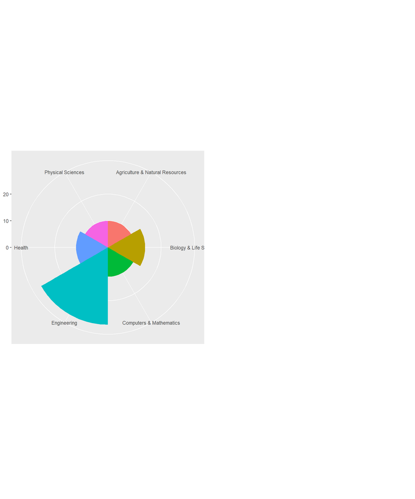

```r
## Objective: Show which major classes fall under which sector; the biggest categories that make up each division
par(mar = c(7, 7, 7, 7))
#coxcomb for STEM by category
STEMbar <- ggplot(data = STEM) +
  geom_bar(mapping = aes(x = Major_category, fill = Major_category), show.legend = F, width = 1) +
  theme(aspect.ratio = 1) +
  labs(x = NULL,  y = NULL)
plot2 <- STEMbar + coord_polar()
grid.arrange(plot2, ncol = 2)
```

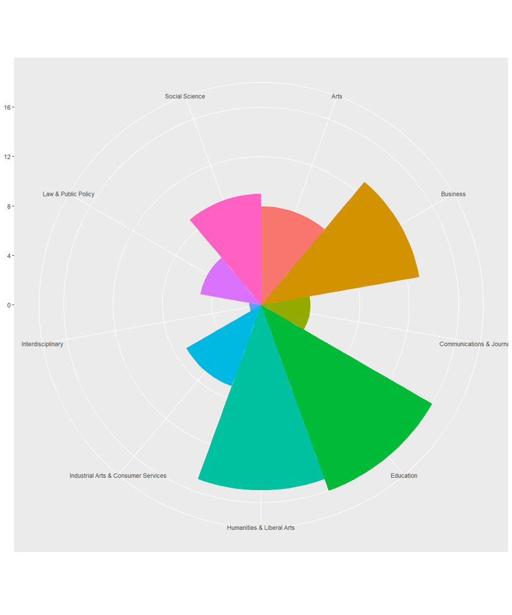

```r
#coxcomb for NONSTEM by category
NONSTEMbar <- ggplot(data = NONSTEM) +
  geom_bar(mapping = aes(x = Major_category, fill = Major_category), show.legend = F, width = 1) +
  theme(aspect.ratio = 1) +
  labs(x = NULL,  y = NULL)
plot2 <- NONSTEMbar + coord_polar()
grid.arrange(plot2, ncol = 1, nrow =1 )
```

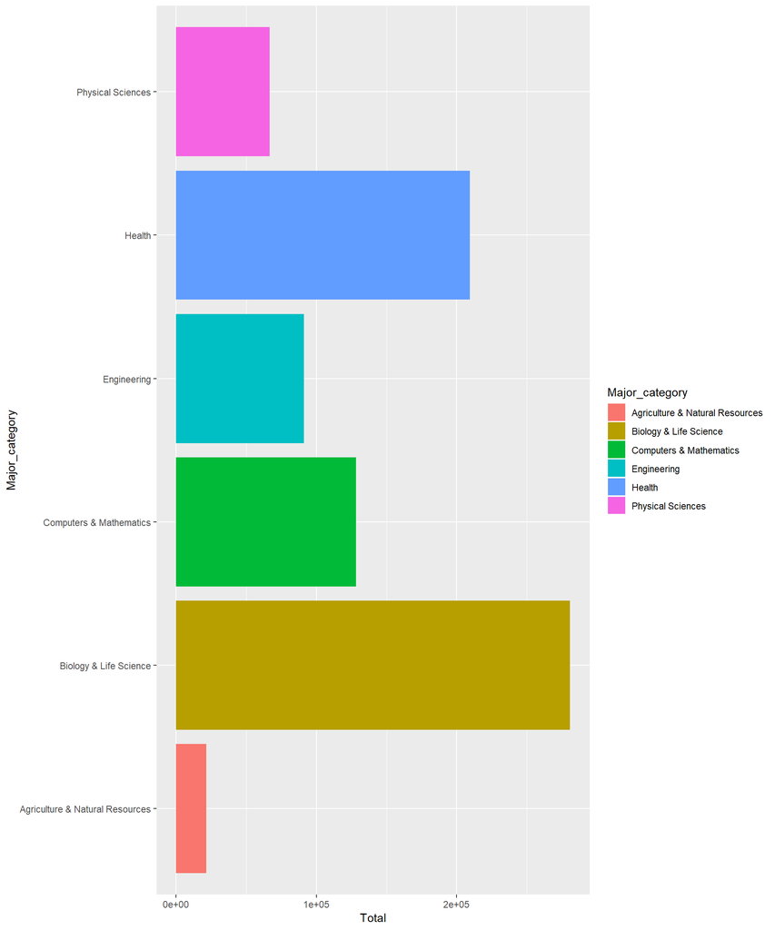

```r
#histogram for Total number of college students by Major Category for both STEM & NONSTEM
#STEM
ggplot(data = STEM, mapping = aes(x = Major_category, y = Total)) +
  geom_histogram(mapping = aes(fill = Major_category), stat = "identity", binwidth = 1000, position = "dodge") +
  coord_flip()
## Warning: Ignoring unknown parameters: binwidth, bins, pad
## Warning: Removed 1 rows containing missing values (geom_bar).
```

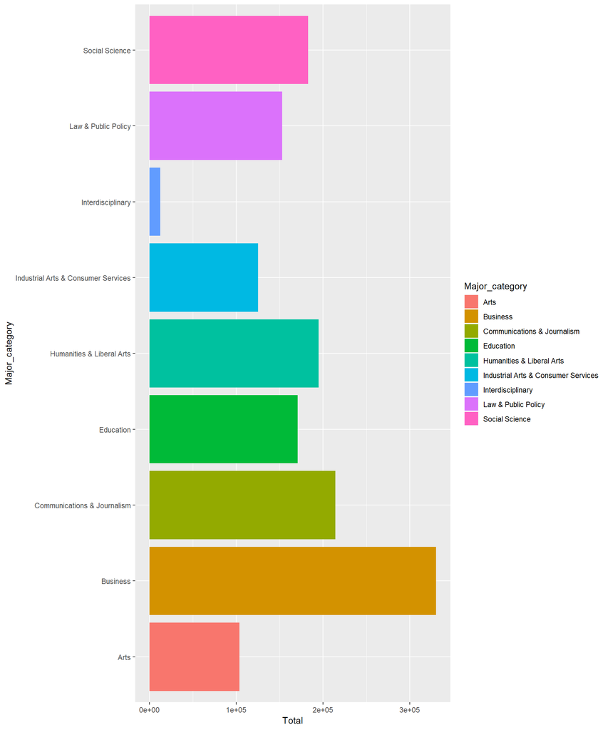

```r
#NONSTEM
ggplot(data = NONSTEM, mapping = aes(x = Major_category, y = Total)) +
  geom_histogram(mapping = aes(fill = Major_category), stat = "identity", binwidth = 1000, position = "dodge") +
  coord_flip()
## Warning: Ignoring unknown parameters: binwidth, bins, pad
```

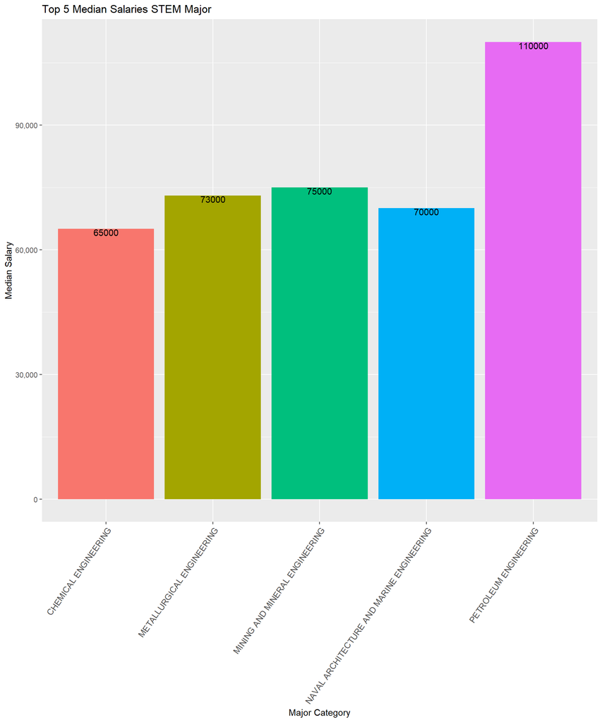

```r
#histogram for top5 stem median salaries
top5stem <-  head(med_sal_STEM, 5)
ggplot(data = top5stem, mapping= aes(x = Major, y = med_salary)) +
  geom_histogram(mapping = aes(fill= Major),  stat = "identity", show.legend = F) +
  scale_y_continuous(labels = scales::comma) +
  geom_text(mapping = aes(label = med_salary), vjust = 1) +
  labs(title = "Top 5 Median Salaries STEM Major", x = "Major Category", y= "Median Salary") +
  theme(axis.text.x = element_text(size = 10,angle = 55,hjust = 1,vjust = 1))
## Warning: Ignoring unknown parameters: binwidth, bins, pad
```

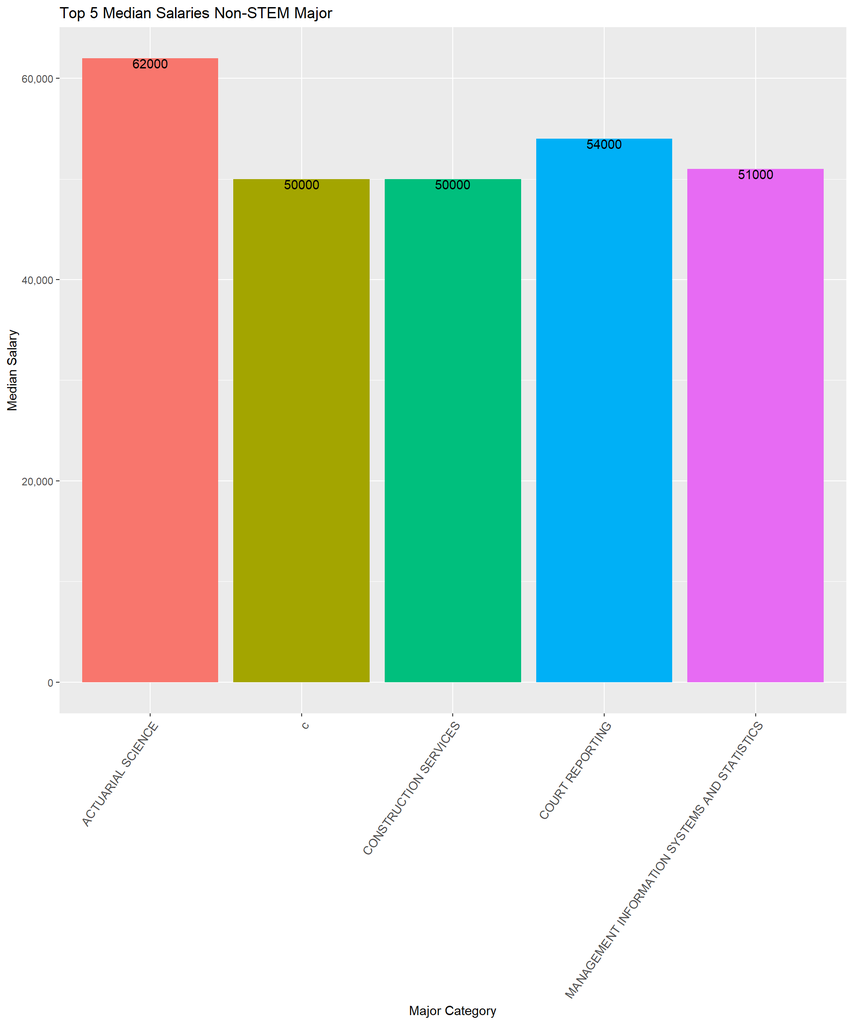

```r
#histogram for top5 nonstem median salaries
top5nonstem <- head(med_sal_NONSTEM, 5)
ggplot(data = top5nonstem, mapping= aes(x = Major, y = med_salary)) +
  geom_histogram(mapping = aes(fill= Major),  stat = "identity", show.legend = F) +
  scale_y_continuous(labels = scales::comma) +
  geom_text(mapping = aes(label = med_salary), vjust = 1) +
  labs(title = "Top 5 Median Salaries Non-STEM Major", x = "Major Category", y= "Median Salary") +
  theme(axis.text.x = element_text(size = 10,angle = 55,hjust = 1,vjust = 1))
## Warning: Ignoring unknown parameters: binwidth, bins, pad
```

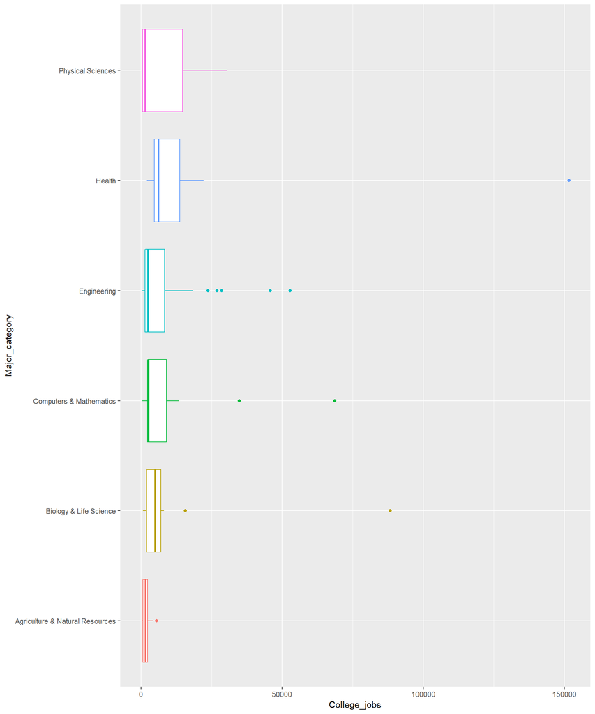

```r
##boxplots to compare the number of college jobs for each specific major division
ggplot(data = STEM) +
geom_boxplot(mapping = aes(x = Major_category, y = College_jobs, color = Major_category), show.legend = F) +
  coord_flip()
```

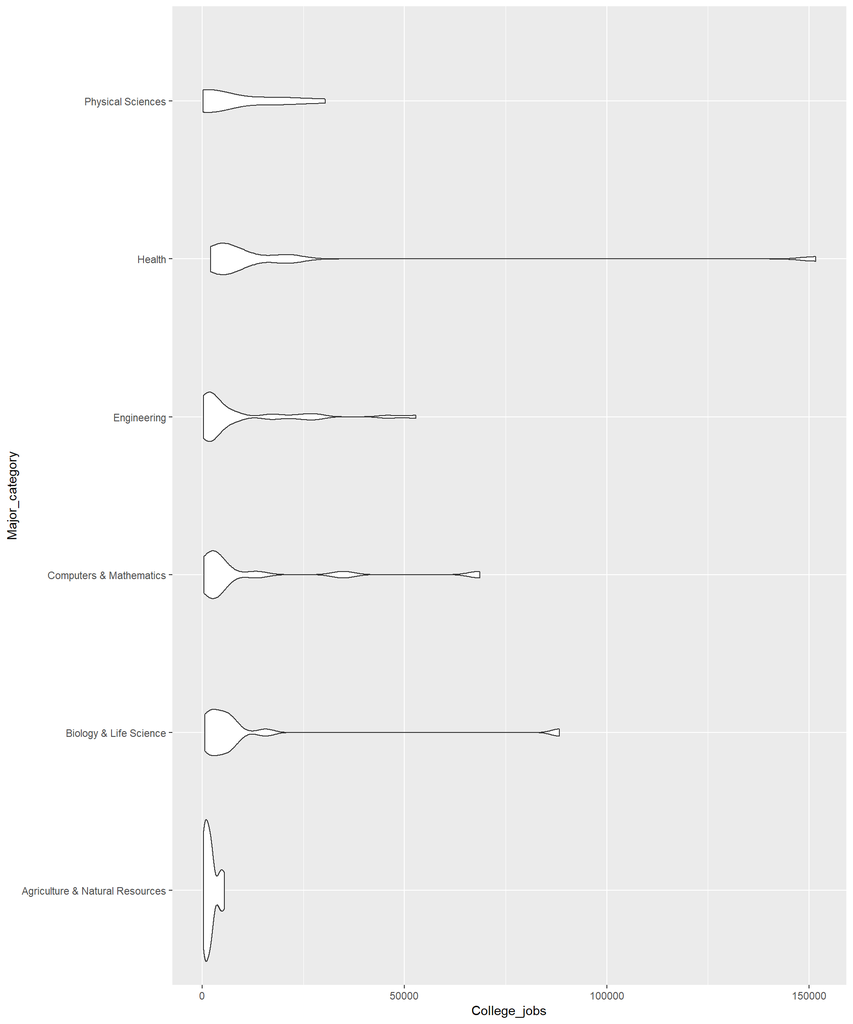

```r
ggplot(data = STEM, mapping = aes(x = Major_category, y = College_jobs)) +
  geom_violin() +
  coord_flip()
```

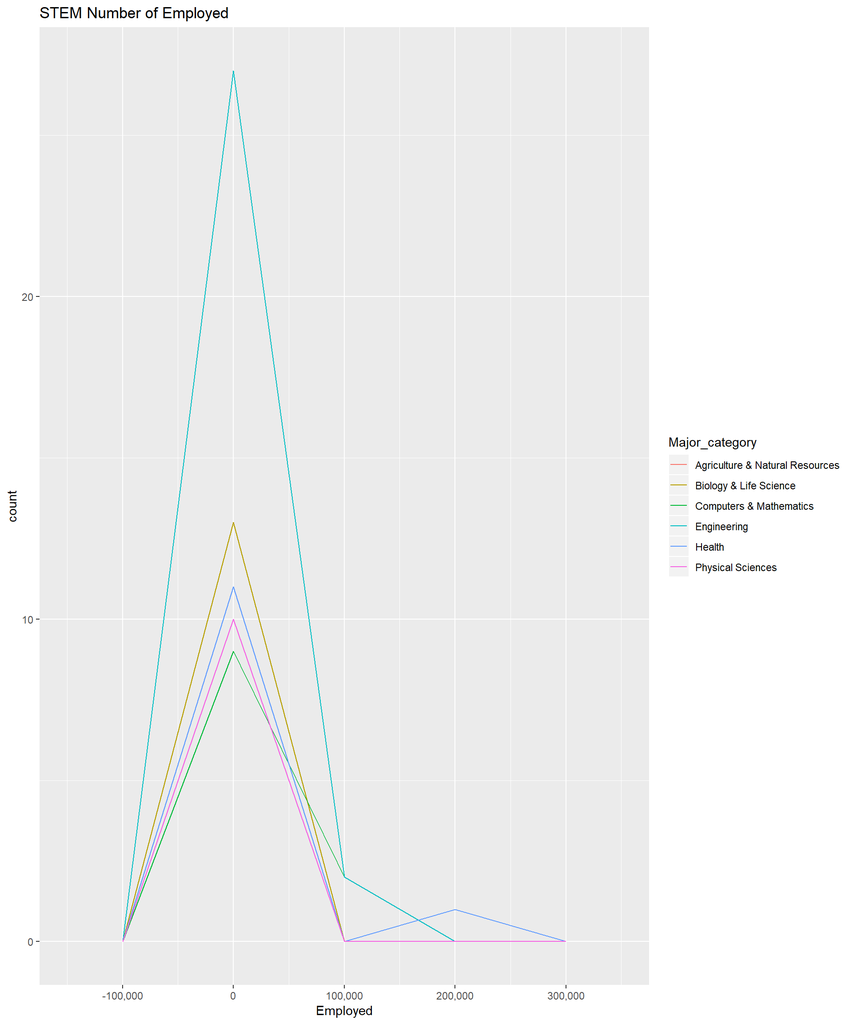

```r
#Frequency plots to show which industry has the most amount of people employed: STEM or NONSTEM
ggplot(data = STEM) +
  geom_freqpoly(mapping = aes(x = Employed, color = Major_category),
                binwidth = 100000) +
  scale_x_continuous(labels = scales::comma) +
  labs(title = "STEM Number of Employed")
```

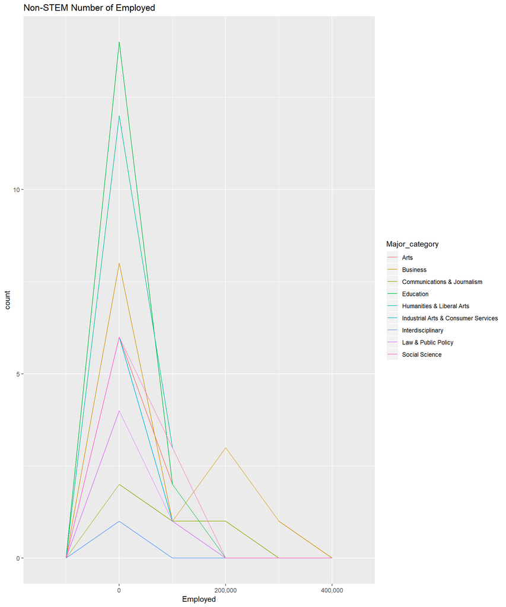

```r
ggplot(data = NONSTEM) +
  geom_freqpoly(mapping = aes(x = Employed, color = Major_category),
                binwidth = 100000) +
  scale_x_continuous(labels = scales::comma) +
  labs(title = "Non-STEM Number of Employed")
```

### (IV.) Modeling

```r
#make a new column; binary => 0s and 1s to label which major is STEM or NONSTEM
recentgrads_SorN <- recentgrads %>% #Creating new table define STEM and NONSTEM as 0s and 1s
  group_by(Major, Major_category) %>%
  mutate(SorN = if(Major_category == "Engineering" | Major_category == "Physical Sciences" |
                   Major_category == "Computers & Mathematics" | Major_category == "Agriculture & Natural Resources"| Major_category == "Health"|
                   Major_category == "Biology & Life Science"){
    n = 1 #STEM is 1
  }else{
    n = 0 #NONSTEM is 0
  }, default = if(Major_category == "Engineering" | Major_category == "Physical Sciences" |
                   Major_category == "Computers & Mathematics" | Major_category == "Agriculture & Natural Resources"| Major_category == "Health"|
                   Major_category == "Biology & Life Science"){
    n = "Yes" #STEM is Yes
  }else{
    n = "No" #NONSTEM is No
  }) %>%
  select(Major, Major_category, SorN, default, Total, Employed, Unemployed, Unemployment_rate, Median, College_jobs)
recentgrads_SorN
## # A tibble: 173 x 10
## # Groups:   Major, Major_category [173]
##    Major Major_category  SorN default Total Employed Unemployed
##    <chr> <chr>          <dbl> <chr>   <dbl>    <dbl>      <dbl>
##  1 PETR~ Engineering        1 Yes      2339     1976         37
##  2 MINI~ Engineering        1 Yes       756      640         85
##  3 META~ Engineering        1 Yes       856      648         16
##  4 NAVA~ Engineering        1 Yes      1258      758         40
##  5 CHEM~ Engineering        1 Yes     32260    25694       1672
##  6 NUCL~ Engineering        1 Yes      2573     1857        400
##  7 ACTU~ Business           0 No       3777     2912        308
##  8 ASTR~ Physical Scie~     1 Yes      1792     1526         33
##  9 MECH~ Engineering        1 Yes     91227    76442       4650
## 10 ELEC~ Engineering        1 Yes     81527    61928       3895
## # ... with 163 more rows, and 3 more variables: Unemployment_rate <dbl>,
## #   Median <dbl>, College_jobs <dbl>
```

**Ran a logistic regression between the ‘SorN’ versus ‘Total’, ‘Unemployment_rate’, ‘Median’, and ‘College_jobs’.**  
**Suprisingly for college_jobs and unemployment_rate the p-values are greater than alpha showing that they are NOT significant predictors for influencing one’s choice to join either STEM or NONSTEM. On the other hand, median salary and total number of students have p-values less than alpha = 0.10 indicating that they’re contributors to the decision between STEM and NONSTEM.**

```r
# set the random seed so that the analysis is reproducible
set.seed(168)
recentgrads_SorN_idx = sample(nrow(recentgrads_SorN), 86) #splitting the data in half
recentgrads_SorN_trn = recentgrads_SorN[recentgrads_SorN_idx, ] #training data
recentgrads_SorN_tst = recentgrads_SorN[-recentgrads_SorN_idx, ] #testing data
rcg_trn_lm = recentgrads_SorN_trn
rcg_tst_lm = recentgrads_SorN_tst


#logit.fit.all
model_glm_all = glm(SorN ~ Total+Unemployment_rate+Median+College_jobs ,
                    data = recentgrads_SorN_trn,
                    family = "binomial")
summary(model_glm_all)
##
## Call:
## glm(formula = SorN ~ Total + Unemployment_rate + Median + College_jobs,
##     family = "binomial", data = recentgrads_SorN_trn)
##
## Deviance Residuals:
##     Min       1Q   Median       3Q      Max
## -2.1990  -0.8799  -0.4259   0.9935   2.1391
##
## Coefficients:
##                     Estimate Std. Error z value Pr(>|z|)
## (Intercept)       -4.964e+00  1.729e+00  -2.872  0.00408 **
## Total             -1.594e-05  8.836e-06  -1.804  0.07130 .
## Unemployment_rate  6.261e-01  8.627e+00   0.073  0.94214
## Median             1.349e-04  4.187e-05   3.223  0.00127 **
## College_jobs       3.065e-05  2.268e-05   1.352  0.17643
## ---
## Signif. codes:  0 '***' 0.001 '**' 0.01 '*' 0.05 '.' 0.1 ' ' 1
##
## (Dispersion parameter for binomial family taken to be 1)
##
##     Null deviance: 117.823  on 84  degrees of freedom
## Residual deviance:  92.102  on 80  degrees of freedom
##   (1 observation deleted due to missingness)
## AIC: 102.1
##
## Number of Fisher Scoring iterations: 5
```

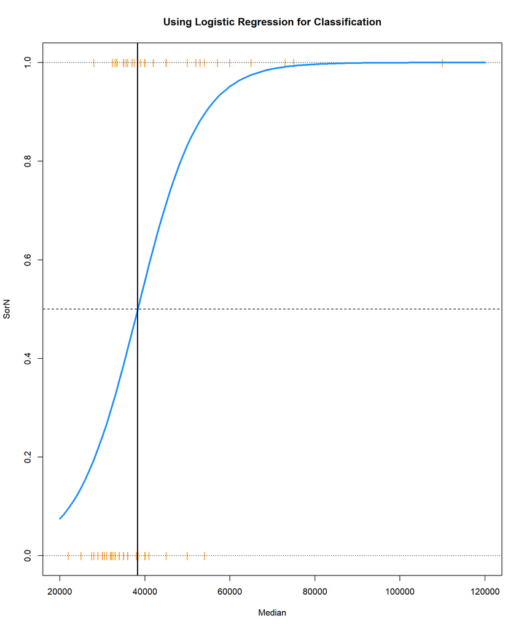

```r
model_glm = glm(SorN ~ Median, data = recentgrads_SorN_trn, family = "binomial")

plot(SorN ~ Median, data = rcg_trn_lm,
     col = "darkorange", pch = "|", ylim = c(0.0, 1.0), xlim=c(20000, 120000),
     main = "Using Logistic Regression for Classification")
#axis(1, at = seq(20000, 120000, by = 10000), las=2)
abline(h = 0, lty = 3)
abline(h = 1, lty = 3)
abline(h = 0.5, lty = 2)
curve(predict(model_glm, data.frame(Median = x), type = "response"),
      add = TRUE, lwd = 3, col = "dodgerblue")
abline(v = -coef(model_glm)[1] / coef(model_glm)[2], lwd = 2)
```

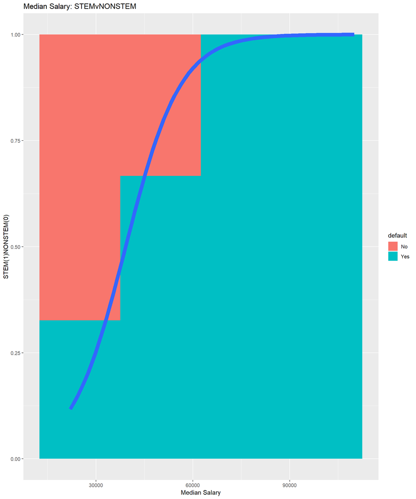

```r
#Estimated conditional probability curve
ggplot(data = recentgrads_SorN, mapping = aes(x = Median)) + ylab("StemorNonSTEM") +
  geom_histogram(mapping = aes(fill = default),
                 binwidth = 25000, position = 'fill') +
  geom_smooth(aes(y = SorN),
              method="glm", method.args=list(family="binomial"), se = F, size = 3) +
  labs(title = "Median Salary: STEMvNONSTEM", x = "Median Salary", y = "STEM(1)NONSTEM(0)")
```

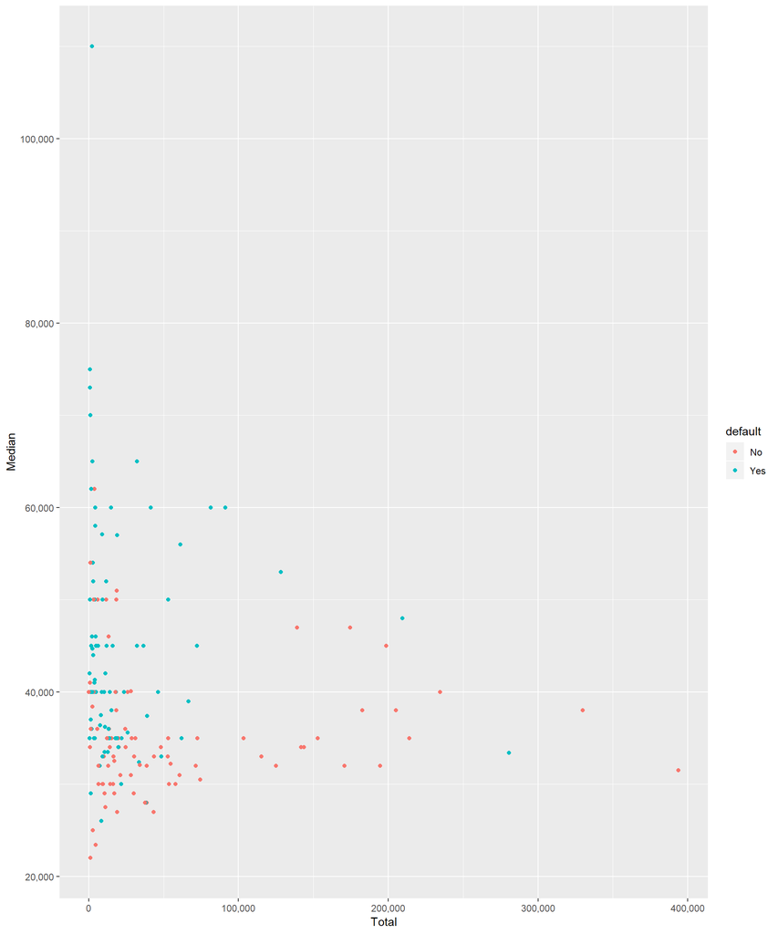

```r
#scatterplot to visualize Total number of students in that major vs Median salary; group_by STEM or NONSTEM
ggplot(recentgrads_SorN) +
  geom_point(mapping = aes(x = Total, y = Median, colour = default)) +
  scale_y_continuous(labels = scales::comma) +
  scale_x_continuous(labels = scales::comma)
## Warning: Removed 1 rows containing missing values (geom_point).
```

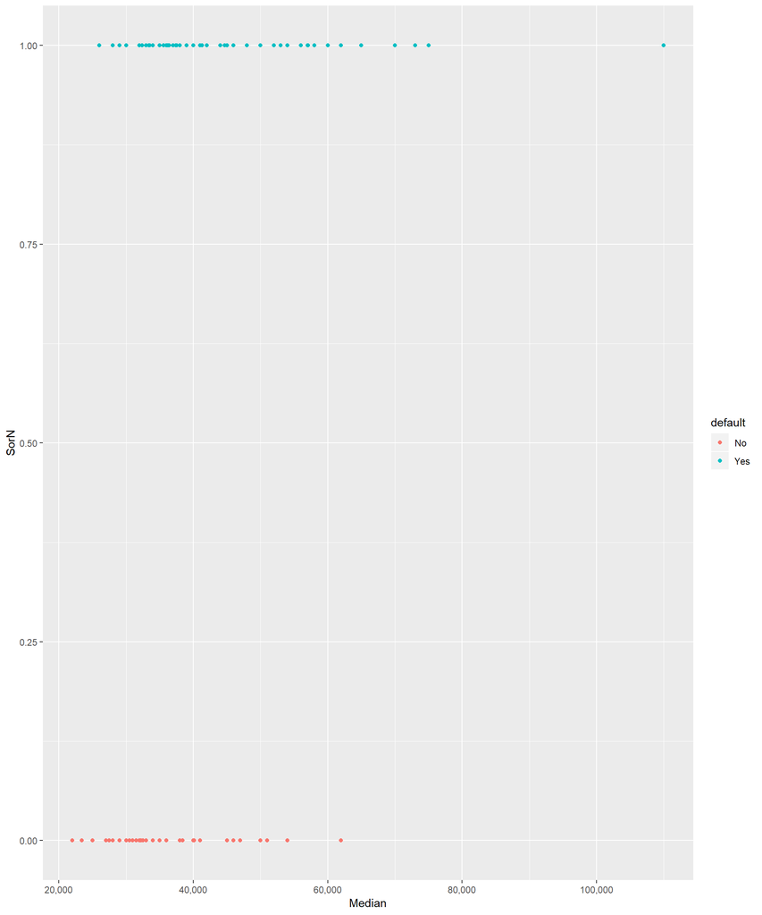

```r
ggplot(data = recentgrads_SorN, mapping = aes(x = Median, y = SorN)) +
  geom_point(mapping = aes(color = default)) +
  scale_x_continuous(labels = scales::comma)
```

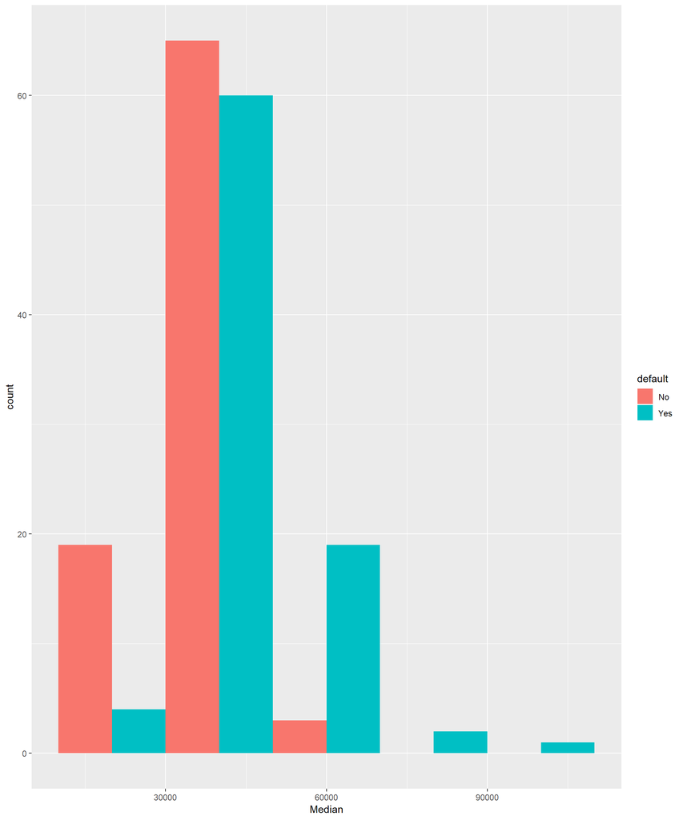

```r
ggplot(data = recentgrads_SorN, mapping = aes(x = Median)) +
  geom_histogram(mapping = aes(fill = default), binwidth = 20000, position = "dodge")
```